# Spam Mail Dataset

### Performanca Measure

```r
confusionMatrix(data = as.factor(PredictRandomForest_spam), reference = as.factor(test_spam$X1), mode = "prec_recall")
```

```
Confusion Matrix and Statistics

          Reference
Prediction   0   1
         0 547  18
         1  11 145

               Accuracy : 0.9598
                 95% CI : (0.9427, 0.9729)
    No Information Rate : 0.7739
    P-Value [Acc > NIR] : <2e-16

                  Kappa : 0.8833

 Mcnemar's Test P-Value : 0.2652

              Precision : 0.9681
                 Recall : 0.9803
                     F1 : 0.9742
             Prevalence : 0.7739
         Detection Rate : 0.7587
   Detection Prevalence : 0.7836
      Balanced Accuracy : 0.9349

       'Positive' Class : 0
```

```r
perf_dt("Random Forest-daily",as.numeric(test_spam$X1),as.numeric(PredictRandomForest_spam))
```

| name | n | mean | sd | FBias | MAPE | RMSE | MAD | WMAPE |
| --- | --- | --- | --- | --- | --- | --- | --- | --- |
| Random Forest-daily | 721 | 1.226075 | 0.4185786 | 0.007918552 | 0.02773925 | 0.007469022 | 0.04022191 | 0.03280543 |

## Stochastic Gradient Boosting(SGB)

```r
set.seed(35)
```

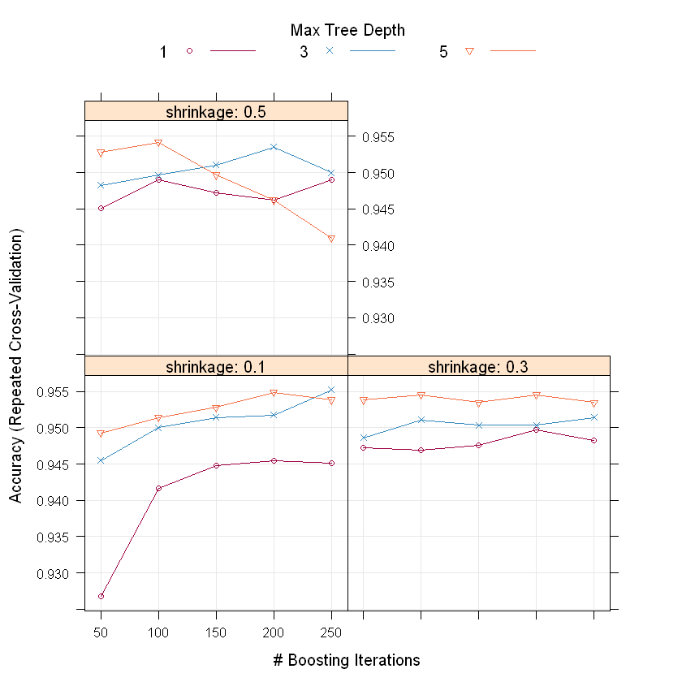

```r
gbmGrid=expand.grid(interaction.depth = c(1, 3, 5),
                        n.trees = (1:5)*50,
                        shrinkage = c(0.1, 0.3, 0.5),
                        n.minobsinnode = 20)


gbm_fit=train(X1 ~ ., data = train_spam,
                 method = "gbm",
                 trControl = fitControl,
                 tuneGrid = gbmGrid,
                 verbose=F) #verbose is an argument from gbm, prints to screen

plot(gbm_fit)
```

```r
predicted_spam_sgb=predict(gbm_fit,test_spam)
```

### Performanca Measure

```r
confusionMatrix(data = as.factor(predicted_spam_sgb), reference = as.factor(test_spam$X1), mode = "prec_recall")
```

```
Confusion Matrix and Statistics

          Reference
Prediction   0   1
         0 545  16
         1  13 147

               Accuracy : 0.9598
                 95% CI : (0.9427, 0.9729)
    No Information Rate : 0.7739
    P-Value [Acc > NIR] : <2e-16

                  Kappa : 0.8843

 Mcnemar's Test P-Value : 0.7103

              Precision : 0.9715
                 Recall : 0.9767
                     F1 : 0.9741
             Prevalence : 0.7739
         Detection Rate : 0.7559
   Detection Prevalence : 0.7781
      Balanced Accuracy : 0.9393

       'Positive' Class : 0
```

```r
perf_dt("First Data Set for Stochastic Gradient Boosting", as.numeric(predicted_spam_sgb), as.numeric(test_spam$X1))
```

| name | n | mean | sd | FBias | MAPE | RMSE | MAD | WMAPE |
| --- | --- | --- | --- | --- | --- | --- | --- | --- |
| First Data Set for Stochastic Gradient Boosting | 721 | 1.221914 | 0.4158221 | -0.003405221 | 0.03120666 | 0.007469022 | 0.04022191 | 0.03291714 |

# General Result for 4 Method for Spam Results

### Linear Regression with Penalty

```r
lrp=confusionMatrix(data = as.factor(prediction_pra_mae_spam_min), reference = as.factor(test_spam$X1), mode = "prec_recall")
lrp
```

```
Confusion Matrix and Statistics

          Reference
Prediction   0   1
         0 538  33
         1  20 130

               Accuracy : 0.9265
                 95% CI : (0.9049, 0.9445)
    No Information Rate : 0.7739
    P-Value [Acc > NIR] : < 2e-16

                  Kappa : 0.7838

 Mcnemar's Test P-Value : 0.09929

              Precision : 0.9422
                 Recall : 0.9642
                     F1 : 0.9531
             Prevalence : 0.7739
         Detection Rate : 0.7462
   Detection Prevalence : 0.7920
      Balanced Accuracy : 0.8809

       'Positive' Class : 0
```

### Decision Tree

```r
dtr=confusionMatrix(data = as.factor(predicted_spam), reference = as.factor(test_spam$X1), mode = "prec_recall")
dtr
```

```
Confusion Matrix and Statistics

          Reference
Prediction   0   1
         0 533  30
         1  25 133

               Accuracy : 0.9237
                 95% CI : (0.9019, 0.942)
    No Information Rate : 0.7739
    P-Value [Acc > NIR] : <2e-16

                  Kappa : 0.7796

 Mcnemar's Test P-Value : 0.5896

              Precision : 0.9467
                 Recall : 0.9552
                     F1 : 0.9509
             Prevalence : 0.7739
         Detection Rate : 0.7393
   Detection Prevalence : 0.7809
      Balanced Accuracy : 0.8856

       'Positive' Class : 0
```

### Random Forest

```r
rfr=confusionMatrix(data = as.factor(PredictRandomForest_spam), reference = as.factor(test_spam$X1), mode = "prec_recall")
rfr
```

```
Confusion Matrix and Statistics

          Reference
Prediction   0   1
         0 547  18
         1  11 145

               Accuracy : 0.9598
                 95% CI : (0.9427, 0.9729)
    No Information Rate : 0.7739
    P-Value [Acc > NIR] : <2e-16

                  Kappa : 0.8833

 Mcnemar's Test P-Value : 0.2652

              Precision : 0.9681
                 Recall : 0.9803
                     F1 : 0.9742
             Prevalence : 0.7739
         Detection Rate : 0.7587
   Detection Prevalence : 0.7836
      Balanced Accuracy : 0.9349

       'Positive' Class : 0
```

### Stochastic Gradient Boosting

```r
sgbr=confusionMatrix(data = as.factor(predicted_spam_sgb), reference = as.factor(test_spam$X1), mode = "prec_recall")
sgbr
```

```
Confusion Matrix and Statistics

          Reference
Prediction   0   1
         0 545  16
         1  13 147

               Accuracy : 0.9598
                 95% CI : (0.9427, 0.9729)
    No Information Rate : 0.7739
    P-Value [Acc > NIR] : <2e-16

                  Kappa : 0.8843

 Mcnemar's Test P-Value : 0.7103

              Precision : 0.9715
                 Recall : 0.9767
                     F1 : 0.9741
             Prevalence : 0.7739
         Detection Rate : 0.7559
   Detection Prevalence : 0.7781
      Balanced Accuracy : 0.9393

       'Positive' Class : 0
```

By looking the Accuracy, it can be said that best performance are optained in the Random Forest and Stochastic Gradient Boosting. Indeed, these 2 model's performance is too similar, which can be understood by looking the Precision, Recall, and F1 score of the models. The biggest difference occurs in the precision and recall values of the model. So, main objective can determine which model must be used. Moreover, performance of the other two model is also similar. Indeed decision tree's approach is more proper for classification problems. The reason behind the similarity can be explained by complexity of the models. Namely, Decision Tree's complexity is less than constructed Linear Regression with lasso, but it still has similar performance compared to the other.